# 大数据分析与挖掘

## 02. how to do exploratory data analysis in PySpark

主讲人：丁平尖

## 使用 Spark 数据绘图

1. 在 Spark DataFrame 中进行计算

```
data_lg = data.withColumn("log_price", F.log(data["price"]))
pdf_lg = data_lg.toPandas()
```

2. 如果数据量较大，则进行采样

```
data_lg = data.withColumn("log_price", F.log(data["price"]))
percent = 40/100
pdf_lg = data_lg.sample(percent, 3).toPandas()
```

3. 使用 `toPandas()` 转换为 Pandas DataFrame
4. 绘图

## Seaborn plotting

- Seaborn tutorial
  - https://seaborn.pydata.org/tutorial.html
- Kimberly Fessel's Intro to Seaborn
  - https://www.youtube.com/watch?v=vaf4ir8eT38&list=PLtPIclEQf-3cG31dxSMZ8KTcDG7zYng1j&index=1
- Seaborn 的图一般分三大类：
  - 关系图（relational plots）：两个或多变量之间的关系
  - 分布图（distribution plots）：单变量或双变量分布形态
  - 类别图（categorical plots）：按类别比较数值

## 流程

- 下载数据集
- 清洗数据
  - 将数值转换为合适的数据类型
  - 移除包含某些空值的行
- 绘制数据
  - 使用 PySpark 计算数值
  - 使用 seaborn 绘制数据（或采样数据）
  - 三类图：关系图、分布图、类别图

## 下载和读取数据集

本项目使用的葡萄酒评论数据集包含三个文件，分别为：

数据于2017年6月15日当周从WineEnthusiast网站抓取。可从kaggle上下载数据

- https://www.kaggle.com/datasets/zynicide/wine-reviews?datasetud=1442

### Spark DataFrame 与 Pandas DataFrame 的差异

| 特点 | Spark DataFrame | Pandas DataFrame |
| --- | --- | --- |
| 处理规模 | 分布式，适合大数据（TB级） | 单机，适合中小数据（GB级） |
| 内存管理 | 自动分布在集群节点，内存高效 | 依赖本地内存，易受限 |
| API风格 | 类SQL，惰性执行（lazy evaluation） | 类Python，立即执行（eager） |
| 数据类型支持 | 支持复杂类型（Array, Map, Struct等） | 主要支持基础类型 |
| 计算性能 | 可并行处理，适合批量和流式数据 | 单线程处理，适合交互式分析 |
| 容错性 | 高，自动恢复失败任务 | 低，需手动处理异常 |
| 生态集成 | 与大数据生态（HDFS, Hive, Delta等）紧密 | 主要与Python数据科学库集成 |

对于Spark DataFrame来说，大多数操作（如select、filter、groupBy等）只是构建一个执行计划，并不会马上处理数据，只有在触发行动操作（如collect、count、display等）时，Spark才会真正执行这些操作并返回结果。这种机制有助于优化执行流程，提高性能和资源利用率。

#### 主要函数差异举例

| 功能 | Spark DataFrame 示例 | Pandas DataFrame 示例 |
| --- | --- | --- |
| 选取列 | `df.select("col1", "col2")` | `df[["col1", "col2"]]` |
| 过滤 | `df.filter(df.col > 0)` | `df[df["col"] > 0]` |
| 分组聚合 | `df.groupBy("col").agg(...)` | `df.groupby("col").agg(...)` |
| 缺失值处理 | `df.dropna()` | `df.dropna()` |
| 新增列 | `df.withColumn("new", ...)` | `df["new"] = ...` |
| 排序 | `df.orderBy("col")` | `df.sort_values("col")` |
| 合并 | `df.join(df2, ...)` | `pd.merge(df, df2, ...)` |
| 转换为Pandas | `df.toPandas()` | - |

> 总结：Spark DataFrame 适合大规模分布式数据处理，Pandas DataFrame 适合本地交互式分析。两者API风格类似，但底层实现和性能特性差异显著。

```python
# 读取 CSV
df1 = spark.read.csv("/Volumes/dataset/winemag/winemag-data/winemag-data-130k-v2.csv", header=True, inferSchema=True, multiLine=True, mode="DROPMALFORMED")
df2 = spark.read.csv("/Volumes/dataset/winemag/winemag-data/winemag-data_first150k.csv", header=True, inferSchema=True, multiLine=True, mode="DROPMALFORMED")
print(f"spark.read.csv返回的数据类型: {type(df1)}")
print(f"df1的数据类型: {type(df1)}")
import pandas as pd
pdf1 = df1.toPandas()
print(f"pdf1的数据类型: {type(pdf1)}")
print(f"df1的列：{df1.columns}")
print(f"df2的列：{df2.columns}")
extra_columns = list(set(df1.columns) - set(df2.columns))
print(f"These columns will be dropped: {extra_columns}")
display(df1.limit(2))
```

```
spark.read.csv返回的数据类型: <class 'pyspark.sql.connect.dataframe.DataFrame'>
df1的数据类型: <class 'pyspark.sql.connect.dataframe.DataFrame'>
pdf1的数据类型: <class 'pandas.core.frame.DataFrame'>
df1的列：['_c0', 'country', 'description', 'designation', 'points', 'price', 'province', 'region_1', 'region_2', 'taster_name', 'taster_twitter_handle', 'title', 'variety', 'winery']
df2的列：['_c0', 'country', 'description', 'designation', 'points', 'price', 'province', 'region_1', 'region_2', 'variety', 'winery']
These columns will be dropped: ['taster_name', 'taster_twitter_handle', 'title']
```

| _c0 | country | description | designation | points | price | province | region_1 | region_2 | taster_name | taster_twitter_handle | title | variety | winery |
| --- | --- | --- | --- | --- | --- | --- | --- | --- | --- | --- | --- | --- | --- |
| 0 | Italy | Aromas include tropical fruit, broom, brimstone and dried herb. The palate isn't overly expressive, offering unripened apple, citrus and dried sage alongside brisk acidity. | Vulkà Bianco | 87 | null | Sicily & Sardinia | Etna | null | Kerin O’Keefe | @kerinokeefe | Nicosia 2013 Vulkà Bianco (Etna) | White Blend | Nicosia |
| 1 | Portugal | This is ripe and fruity, a wine that is smooth while still structured. Firm tannins are filled out with juicy red berry fruits and freshened with acidity. It's already drinkable, although it will cert… | Avidagos | 87 | 15.0 | Douro | null | null | Roger Voss | @vossroger | Quinta dos Avidagos 2011 Avidagos Red (Douro) | Portuguese Red | Quinta dos Avidagos |

```python
# Combined two datasets
df1 = df1.drop(*extra_columns) # drop extra columns in df1
print(df1.columns)
data = df1.union(df2).drop('_c0').distinct()
print(data.columns)
display(data.limit(2))
# data 是合并后的葡萄酒评论数据集，包含以下字段：
# country: 产国
# description: 品酒师对葡萄酒的描述
# designation: 葡萄酒的指定名称
# points: 品酒师评分
# price: 葡萄酒价格
# province: 产省
# region_1: 产区1
# region_2: 产区2
# variety: 葡萄品种
# winery: 酒庄名称
```

```
['_c0', 'country', 'description', 'designation', 'points', 'price', 'province', 'region_1', 'region_2', 'variety', 'winery']
['country', 'description', 'designation', 'points', 'price', 'province', 'region_1', 'region_2', 'variety', 'winery']
```

| country | description | designation | points | price | province | region_1 | region_2 | variety | winery |
| --- | --- | --- | --- | --- | --- | --- | --- | --- | --- |
| France | Fruity and ripe, the wine also has some solid structure to give it a core of dark tannins. The black-currant fruits are developing well, bringing their crispness to the party. Drink this wine from 201… | null | 89 | 14.0 | Bordeaux | Bordeaux Supérieur | null | Bordeaux-style Red Blend | Château Bois Chantant |
| Austria | This is a crisp, but also rich style of Federspiel. It is full of ripe pear and apple flavor as well as a fine pinch of pepper. Acidity creeps in the background to balance this ready-to-drink wine. Sc… | Loibner Klostersatz Federspiel | 90 | null | Wachau | null | null | Grüner Veltliner | F X Pichler |

```python
# Some minor data cleaning
# define string and number UDFs
from typing import Optional
from pyspark.sql import DataFrame
import pyspark.sql.functions as F
import pyspark.sql.types as T
import pandas as pd

# 装饰器用于简化函数功能的扩展，例如在 PySpark 中注册 UDF（用户自定义函数）时，
# 可以通过 @F.udf 装饰器直接将普通 Python 函数转换为 Spark 可用的 UDF，
# 这样可以方便地在 DataFrame 操作中调用，提高代码的可读性和复用性。
@F.udf(T.BooleanType()) # UDF to check if a value is a number
def is_a_number(value: Optional[str]) -> bool:
    if not value:
        return True
    try:
        _ = float(value)
    except ValueError:
        return False
    return True

@F.udf(T.BooleanType())
def is_a_string(value: Optional[str]) -> bool:
    if not value:
        return True
    if isinstance(value, str):
        return True
    return False

CONTINUOUS_COLUMNS = ['points', 'price', ]
CATEGORICAL_COLUMNS = list(set(data.columns) - set(CONTINUOUS_COLUMNS))
print(CONTINUOUS_COLUMNS)
print(CATEGORICAL_COLUMNS)
```

```
['points', 'price']
['region_1', 'country', 'designation', 'variety', 'winery', 'province', 'region_2', 'description']
```

```python
# Spark DataFrame 的 where 方法用于根据条件筛选出满足条件的行，等价于 filter 方法。
# 例如，data.where(~is_a_number('points')) 表示筛选出 'points' 列不是数字的行。
# 语法：data.where(条件表达式)
# 返回：只包含满足条件的行的 DataFrame
display(data.where(~is_a_number('points')))
# display 函数用于在 Databricks notebook 中以可视化表格的形式展示 DataFrame 或其他对象，方便数据浏览和分析。
display(data.where(is_a_number('points')).limit(2))
```

| country | description | designation | points | price | province | region_1 | region_2 | variety | winery |
| --- | --- | --- | --- | --- | --- | --- | --- | --- | --- |

| country | description | designation | points | price | province | region_1 | region_2 | variety | winery |
| --- | --- | --- | --- | --- | --- | --- | --- | --- | --- |
| Italy | Aromas include tropical fruit, broom, brimstone and dried herb. The palate isn't overly expressive, offering unripened apple, citrus and dried sage alongside brisk acidity. | Vulkà Bianco | 87 | null | Sicily & Sardinia | Etna | null | White Blend | Nicosia |
| Portugal | This is ripe and fruity, a wine that is smooth while still structured. Firm tannins are filled out with juicy red berry fruits and freshened with acidity. It's already drinkable, although it will cert… | Avidagos | 87 | 15.0 | Douro | null | null | Portuguese Red | Quinta dos Avidagos |

```python
# DataFrame.count() 用于统计 Spark DataFrame 的总行数，是常用的行动操作之一。
# 例如，print(data.count()) 会输出 data 数据集的行数。
# 该方法会触发 Spark 的实际计算，将所有分布式分区的数据聚合，返回一个整数结果。
print(data.count())
bad_rows = data.where(~is_a_number('points') | ~is_a_number('price')).count()
print(bad_rows)
print(f"Dropping {bad_rows} with numeric values in non-numeric columns")
data = data.where(is_a_string('province') & is_a_string('region_1') & is_a_string('region_2') & is_a_string('variety'))
```

```
170491
0
Dropping 0 with numeric values in non-numeric columns
```

```python
# 打印转换前的连续型数据列的数据类型
print("Before casting:")
for col in CONTINUOUS_COLUMNS:
    print(f"{col}: {data.schema[col].dataType}")
# 将连续型数据列转换为 double 类型，确保后续分析和计算的数值精度
for col in CONTINUOUS_COLUMNS:
    data = data.withColumn(col, F.col(col).cast('double'))
```

```
Before casting:
points: StringType()
price: StringType()
```

```python
# Drop rows with null values in continuous columns
# *CONTINUOUS_COLUMNS 的含义是将列表 CONTINUOUS_COLUMNS 中的元素作为单独的参数传递
# 例如，如果 CONTINUOUS_COLUMNS = ['points', 'price']，则 *CONTINUOUS_COLUMNS 等价于 'points', 'price'
data = data.na.drop(subset=[*CONTINUOUS_COLUMNS])
# Drop rows with null values in other columns
data = data.dropna(subset=['variety', 'country'])
display(data.limit(2))
```

| country | description | designation | points | price | province | region_1 | region_2 | variety | winery |
| --- | --- | --- | --- | --- | --- | --- | --- | --- | --- |
| US | Tart and snappy, the flavors of lime flesh and rind dominate. Some green pineapple pokes through, with crisp acidity underscoring the flavors. The wine was all stainless-steel fermented. | null | 87.0 | 14.0 | Oregon | Willamette Valley | Willamette Valley | Pinot Gris | Rainstorm |
| Portugal | This is ripe and fruity, a wine that is smooth while still structured. Firm tannins are filled out with juicy red berry fruits and freshened with acidity. It's already drinkable, although it will cert… | Avidagos | 87.0 | 15.0 | Douro | null | null | Portuguese Red | Quinta dos Avidagos |

```python
# Basic summary
# data summary
display(data.summary())
```

| summary | country | description | designation | points | price | province | region_1 | region_2 | variety | winery |
| --- | --- | --- | --- | --- | --- | --- | --- | --- | --- | --- |
| count | 157598 | 157598 | 110728 | 157598 | 157598 | 157598 | 131982 | 67301 | 157598 | 157598 |
| mean | null | null | 1438.9025128205128 | 88.19423469840987 | 34.66431680605084 | null | null | null | null | Infinity |
| stddev | null | null | 6668.827060821776 | 3.15080267784541 | 39.8498680318638 | null | null | null | null | NaN |
| min | Albania | "An oddball of an eiswein. Bizarre earthy, brothy notes combine with honeyed sweetness to make for an ""interesting"" tasting experience." | """M""" | 80.0 | 4.0 | Achaia | Abruzzo | California Other | Abouriou | 1+1=3 |
| 25% | null | null | 120.0 | 86.0 | 16.0 | null | null | null | null | 1850.0 |
| 50% | null | null | 446.0 | 88.0 | 25.0 | null | null | null | null | 1850.0 |
| 75% | null | null | 1769.0 | 90.0 | 40.0 | null | null | null | null | 1919.0 |
| max | Uruguay | “Wow” is the first word that comes to mind when tasting this superconcentrated and immensely fruity wine. It practically overwhelms the nose and the palate with ripe, jammy boysenberry and blackberry,… | “Champ” Lightnin' Lane | 100.0 | 3300.0 | Župa | Zonda Valley | Willamette Valley | Žilavka | Štoka |

```python
import pyspark.sql.types as T
import pyspark.sql.functions as F
import pandas as pd

# 使用 pandas_udf 定义一个 Spark UDF，将评分 points 列分为等级 grade
# 评分区间划分：A: >=95, B: >=85, C: >=75, D: 其他
@F.pandas_udf(T.StringType())
def points_category(points: pd.Series) -> pd.Series:
    def category(points):
        if points >= 95:
            return 'A'
        elif points >= 85:
            return 'B'
        elif points >= 75:
            return 'C'
        else:
            return 'D'
    return points.apply(category)

data = data.withColumn('grade', points_category(data['points'])).orderBy('grade', 'country', 'variety')
```

```python
my_columns = list(set(data.columns) - {'description'})
data = data.select(*my_columns)
display(data.limit(2))
```

| region_1 | grade | country | designation | variety | winery | province | points | region_2 | price |
| --- | --- | --- | --- | --- | --- | --- | --- | --- | --- |
| Tupungato | A | Argentina | Gran Corte Las Divas Vineyard | Bordeaux-style Red Blend | Riglos | Mendoza Province | 96.0 | null | 50.0 |
| Mendoza | A | Argentina | Vineyard Selection | Bordeaux-style Red Blend | Finca Perdriel | Mendoza Province | 95.0 | null | 62.0 |

## dataset to pandas

- Graphs are generated from Pandas
- Some calculations are done in PySpark and then converted to Pandas

```python
# 采样大数据集并转换为 Pandas DataFrame，便于后续绘图和分析
print(f"Original rows: {data.count()}")
percent = 25/100
sample = data.sample(percent, 3)
print(f"Sampled {percent:.2f}% rows: {sample.count():,}")
```

```
Original rows: 157598
Sampled 0.25% rows: 39,156
```

```python
# Full dataset to pandas
pdf = data.toPandas()
```

## Common plots using Seaborn

- Seaborn plots: replot, displot, catplot

```python
import seaborn as sns
import numpy as np
import matplotlib.pyplot as plt
# databricks (sampled) histogram of price
print(data.count())
display(data.select('price').limit(3))
```

```
157598
```

| price |
| --- |
| 50.0 |
| 62.0 |
| 74.0 |

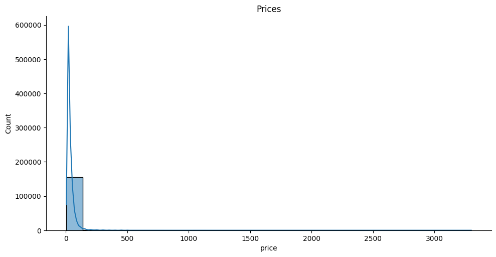

```python
# Price distribution plot
sns.displot(data=pdf, x='price', kde=True, bins=25, height=5, aspect=2).set(title='Prices')
```

```python
# 为什么使用 log(price)？
# 价格分布通常高度偏斜（右偏），大部分葡萄酒价格集中在较低区间，少数价格极高。
# 对价格取对数（log(price)）可以：
# 1. 缓解极端值影响，使分布更接近正态，有利于可视化和统计分析。
# 2. 便于发现价格变化的相对影响（如价格翻倍），而非绝对变化。
# 3. 在回归等建模场景下，提升模型拟合效果和解释性。
import pyspark.sql.functions as F
# Spark SQL 函数如 F.log('price')、F.col('price') 等，参数可以直接写列名字符串（如 'price'），
# 因为这些函数会在 DataFrame 的上下文中查找对应的列，无需指定 DataFrame 名称。
# 例如，data.select(F.log('price')) 会在 data 这个 DataFrame 中查找 'price' 列并对其取对数。
# 这与 Pandas 的 df['price'] 不同，Pandas 需显式指定 DataFrame。
# Spark 的 select、withColumn、filter 等方法都支持这种写法，便于链式操作和表达式组合。
display(data.select(F.log('price')).limit(3))
```

| ln(price) |
| --- |
| 3.912023005428146 |
| 4.127134385045092 |
| 4.304065093204169 |

## 考虑数据存储位置

- Spark 数据存储在集群中
- Pandas 数据存储在单台计算机上

## 推荐做法

- 在 Spark DataFrame 中进行计算
- 如果数据量大，则进行采样
- 使用 `toPandas()` 转换为 Pandas DataFrame
- 绘图

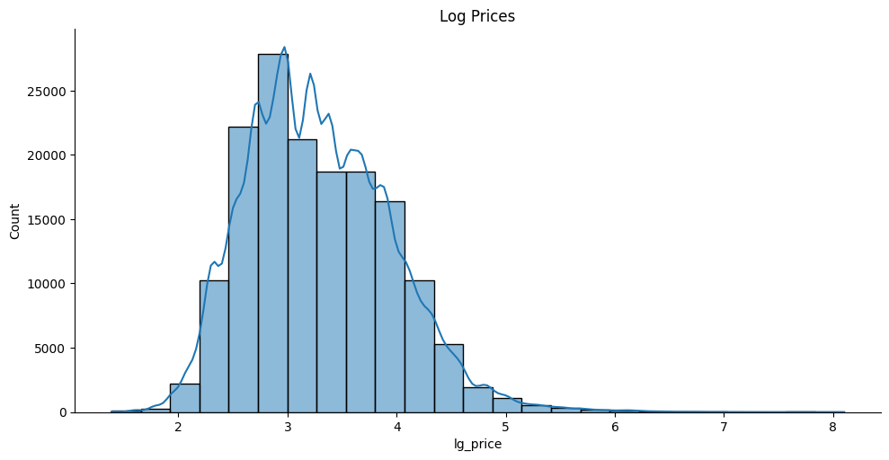

```python
# 在 Spark DataFrame data 中新增一列 'lg_price'，其值为 'price' 列取自然对数后的结果。
# F.log(data['price']) 表示对 'price' 列应用 Spark SQL 的 log 函数（自然对数），
# withColumn 用于添加新列或替换已有列，结果返回新的 DataFrame data_lg。
data_lg = data.withColumn('lg_price', F.log('price'))
pdf_lg = data_lg.toPandas()
sns.displot(data=pdf_lg, x='lg_price', kde=True, bins=25, height=5, aspect=2).set(title='Log Prices')
```

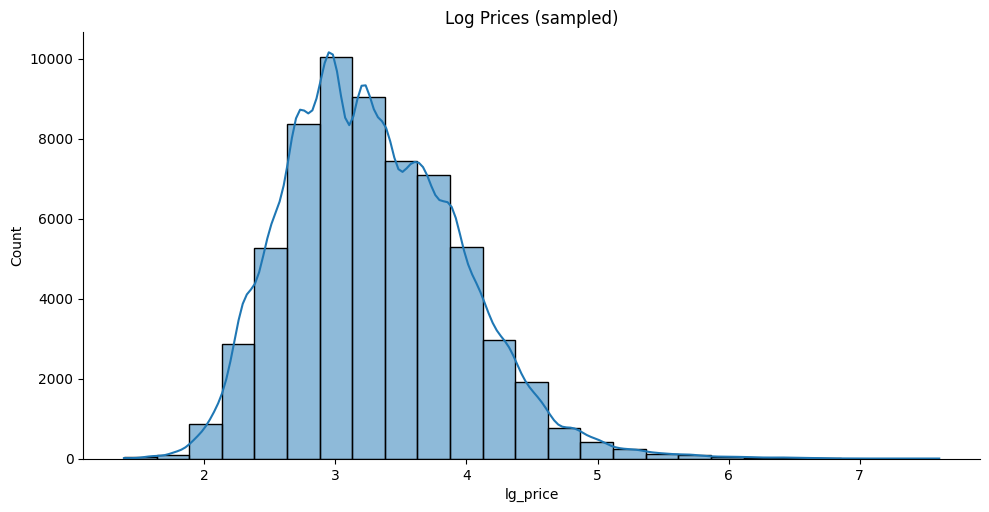

```python
# Sample of Spark log price data plotted from Pandas (for big data)
data_lg = data.withColumn('lg_price', F.log(data['price']))
percent = 40/100
# .sample(fraction, seed) 是 Spark DataFrame 的采样方法
# fraction: 采样比例（0~1之间），如 0.4 表示采样 40% 的数据
# seed: 随机种子，保证采样结果可复现
# 返回一个新的 DataFrame，包含随机采样的部分数据
pdf_lg = data_lg.sample(percent, 3).toPandas()
sns.displot(data=pdf_lg, x='lg_price', kde=True, bins=25, height=5, aspect=2).set(title='Log Prices (sampled)')
```

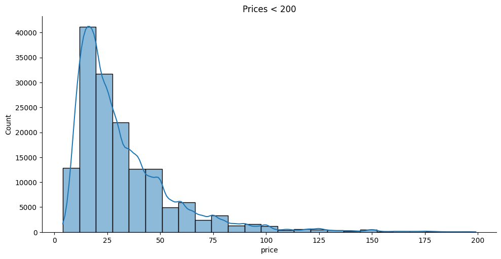

```python
# More distribution plots
# Price<200 distribution plot (with kde)
pdf_200 = pdf[pdf['price']<200]
sns.displot(data=pdf_200, x='price', kde=True, bins=25, height=5, aspect=2).set(title='Prices < 200')
```

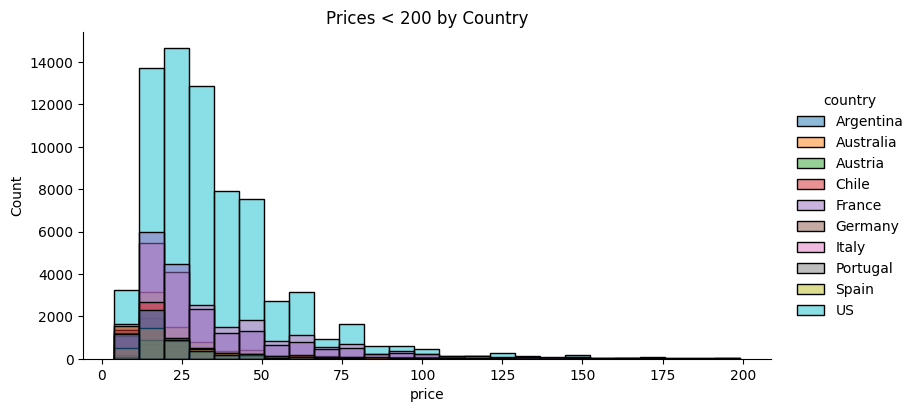

```python
# .alias() 用于为 DataFrame 列或聚合结果指定新的列名，便于后续引用和结果展示。
country_pdf = data.groupby('country').agg(F.count('country').alias('count'),
                                                  F.avg('price').alias('price'),
                                                  F.avg('points').alias('points'))\
                                                    .orderBy('count', ascending=False).where("count > 1000").toPandas()
countries = country_pdf['country'].head(10).tolist()
# 只保留在 countries 列表中的国家，并绘制分布图
plot_data = pdf[pdf['country'].isin(countries) & (pdf['price']<200)]
sns.displot(data=plot_data, x='price', bins=25, hue='country', height=4, aspect=2).set(title='Prices < 200 by Country')
```

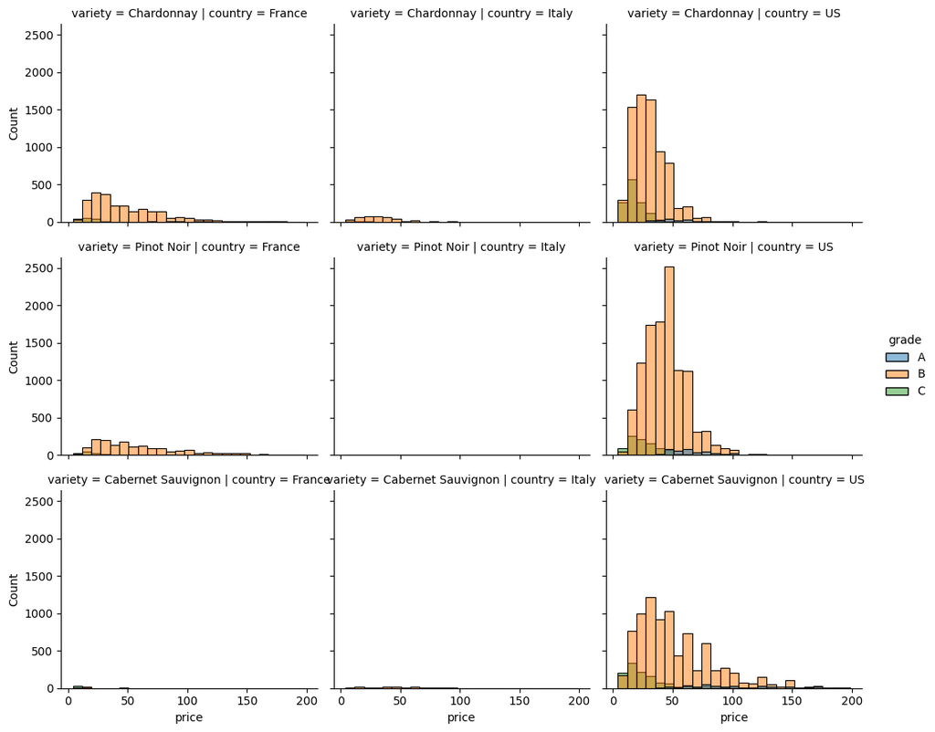

```python
# 按品种和国家分组的价格分布图（Facet Grid）
# countries: 选取评论数最多的前3个国家
countries = country_pdf['country'].head(3).tolist()
# varieties: 选取评论数最多的前3个葡萄品种
variety_lists = data.groupby('variety').agg(F.count('variety').alias('count'))\
    .orderBy('count', ascending=False).select('variety').limit(3).toPandas().values.tolist()
varieties = [item for sublist in variety_lists for item in sublist]
# 只保留价格小于200的样本，按品种和国家分面，按等级着色
sns.displot(data=pdf[(pdf['country'].isin(countries)) & (pdf['variety'].isin(varieties)) & (pdf['price']<200)],
            x='price', bins=25, hue='grade', row='variety', col='country', height=3, aspect=1.2)
```

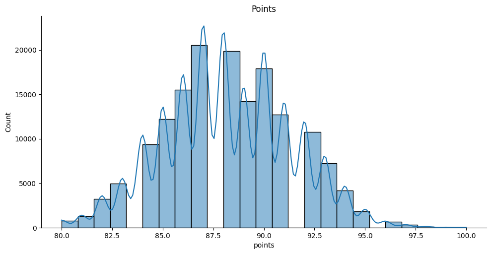

```python
# points 分布图
# 使用 Seaborn 绘制评分（points）分布直方图，带核密度估计（kde）
# 评分区间通常用于评估葡萄酒品质，分布图有助于观察评分集中区间和极端值
sns.displot(data=pdf, x='points', kde=True, bins=25, height=5, aspect=2).set(title='Points')
```

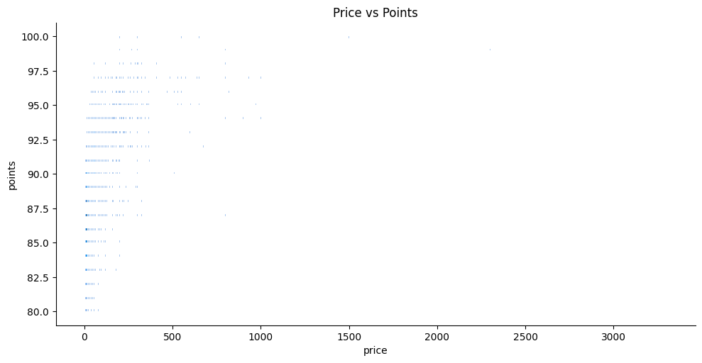

```python
# 价格与评分的分布图（二维直方图）
sns.displot(data=pdf, x='price', y='points', height=5, aspect=2).set(title='Price vs Points')
```

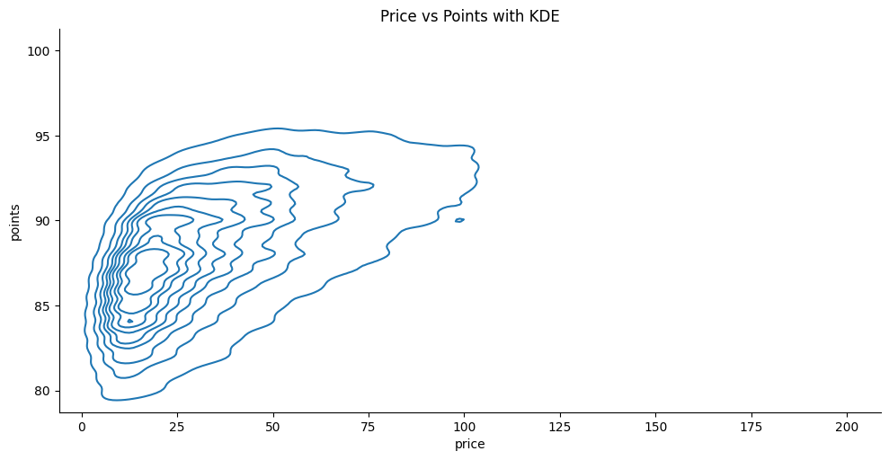

```python
sns.displot(data=pdf[pdf['price']<200], x='price', y='points', kind='kde', height=5, aspect=2).set(title='Price vs Points with KDE')
```